# Apply OE

Apply OE is the built-in end-to-end atmospheric correction pipeline, and is the easiest way to run Isofit. Apply OE is run via a command line interface (CLI) tool accessed with a terminal call:

```
isofit apply_oe --help
```

The function docstring is printed when this command is run within a terminal window, and acts as a guide for how to run the function.

```python
from isofit.utils.apply_oe import apply_oe

print(apply_oe.__doc__)
```

from isofit.utils.apply_oe import apply_oe print(apply_oe.__doc__)

```
    Applies OE over a flightline using an atmospheric radiative transfer engine. This executes
    ISOFIT in a generalized way, accounting for the types of variation that might be
    considered typical.

    Observation (obs) and location (loc) files are used to determine appropriate
    geometry lookup tables and provide a heuristic means of determining atmospheric
    water ranges.

    Parameters
    ----------
    input_radiance : str
        Radiance data cube. Expected to be ENVI format
    input_loc : str
        Location data cube of shape (Lon, Lat, Elevation). Expected to be ENVI format
    input_obs : str
        Observation data cube of shape:
            (path length, to-sensor azimuth, to-sensor zenith,
            to-sun azimuth, to-sun zenith, phase,
            slope, aspect, cosine i, UTC time)
        Expected to be ENVI format
    working_directory : str
        Directory to stage multiple outputs, will contain subdirectories
    sensor : str
        The sensor used for acquisition, will be used to set noise and datetime
        settings
    surface_path : str
        Path to surface model or json dict of surface model configuration
    copy_input_files : bool, default=False
        Flag to choose to copy input_radiance, input_loc, and input_obs locally into
        the working_directory
    modtran_path : str, default=None
        Location of MODTRAN utility. Alternately set with `MODTRAN_DIR` environment
        variable
    wavelength_path : str, default=None
        Location to get wavelength information from, if not specified the radiance
        header will be used
    surface_category : str, default="multicomponent_surface"
        The type of ISOFIT surface priors to use.  Default is multicomponent_surface
    aerosol_climatology_path : str, default=None
        Specific aerosol climatology information to use in MODTRAN
```

[output cut: 102 more lines]

```
        with one number per instrument channel.
    terrain_style : str, default=dem
        Flag to set the terrain style.  dem uses provided obs values, flat sets the surface to the spheroid

    References
    ----------
    D.R. Thompson, A. Braverman,P.G. Brodrick, A. Candela, N. Carbon, R.N. Clark,D. Connelly, R.O. Green, R.F.
    Kokaly, L. Li, N. Mahowald, R.L. Miller, G.S. Okin, T.H.Painter, G.A. Swayze, M. Turmon, J. Susilouto, and
    D.S. Wettergreen. Quantifying Uncertainty for Remote Spectroscopy of Surface Composition. Remote Sensing of
    Environment, 2020. doi: https://doi.org/10.1016/j.rse.2020.111898.

    sRTMnet emulator:
    P.G. Brodrick, D.R. Thompson, J.E. Fahlen, M.L. Eastwood, C.M. Sarture, S.R. Lundeen, W. Olson-Duvall,
    N. Carmon, and R.O. Green. Generalized radiative transfer emulation for imaging spectroscopy reflectance
    retrievals. Remote Sensing of Environment, 261:112476, 2021.doi: 10.1016/j.rse.2021.112476.
```

The Apply OE function can leverage a large number of input parameters, but most are optional. The important inputs are the non-optional arguments:

`INPUT_RADIANCE` `INPUT_LOC` `INPUT_OBS` `WORKING_DIRECTORY` `SENSOR` and `--surface_path`.

#### `INPUT_RADIANCE`

The data is at-sensor radiance in units of $\mu W \, cm^{-2} \, nm^{-1} \, sr^{-1} $. You may leverage **isofit.core.units** module which offers many common conversions. The .hdr file should be used to store the wavelength and fwhm.

#### `INPUT_LOC`

1. **Longitude [degrees]**
   - Range is -180 to 180
2. **Latitude [degrees]**
   - Range is -90 to 90
3. **Elevation [meters]**
   - Above mean sea level

#### `INPUT_OBS`

Note: the names of the keys do not need to match exactly, only the order matters.

1. **Path length [meters]**
   - Defined as the slant path from the sensor to the surface
2. **To-sensor azimuth, $\phi_v$ [degrees]**
   - Ranges from 0-360, measured clockwise from north
3. **To-sensor zenith, $\theta_v$ [degrees]**
   - Ranges from 0-90, measured from zenith
4. **To-sun azimuth, $\phi_s$ [degrees]**
   - Ranges from 0-360, measured clockwise from north
5. **To-sun zenith, $\theta_s$ [degrees]**
   - Ranges from 0-90, measured from zenith
6. **Phase angle, $\xi$ [degrees]**
   - $cos(\xi) = cos(\theta_s) \, cos(\theta_v) \, + \, sin(\theta_s) \, sin(\theta_v) \, cos(\phi_s - \phi_v)$
   - $\xi = arccos(cos(\xi))$
7. **Slope, $S$ [degrees]**
   - Ranges from 0-90
8. **Aspect, $A$ [degrees]**
   - Ranges from 0-360, measured clockwise from north
9. **Cosine of the local solar illumination angle, $cos(i)$ [unitless]**
   - $cos(i) = cos(\theta_s) \, cos(S) \, + \, sin(\theta_s) \, sin(S) \, cos(\phi_s - A) $
10. **UTC time [decimal]**
    - Ranges from 0 - 24
11. **Earth-sun distance [AU]**
    - Astronomical Unit as a function of day of year

## How do you run Apply OE?

The script is run via the CLI. For example:

> `IC=$(isofit path examples)/image_cube/small` sets the environment variable `IC` to the output of the command `isofit path examples/image_cube/small`. This is just used to reuse the same output for multiple arguments. Depending on the user's isofit installation environment, this path may vary. This command ensures the correct path is retrieved

```
  IC=$(isofit path examples)/image_cube/small EX=$(isofit path examples)/image_cube/small \
  isofit apply_oe \
  $IC/ang20170323t202244_rdn_7000-7010 \
  $IC/ang20170323t202244_loc_7000-7010 \
  $IC/ang20170323t202244_obs_7000-7010 \
  $EX \
  ang \
  --surface_path $EX/configs/surface.json \
  --emulator_base $(isofit path srtmnet --key file) \
  --n_cores 10 \
  --presolve \
```

Here,

```
$IC/ang20170323t202244_rdn_7000-7010
$IC/ang20170323t202244_loc_7000-7010
$IC/ang20170323t202244_obs_7000-7010
```

are the radiance, location, and observational geometry files respectively. The `\` tells the CLI call to expect a multi-line input. The remaining two required parameters are `ang`, the sensor designation (AVIRIS-NG), and the `--surface_path` pointing to the surface configuration file which will be built at runtime.

The remaining arguments set Apply OE to run with:

1. `--emulator_base` points isofit to the location of the sRTMnet emulator to usse as the radiative transfer engine (RTE)
2. `--n_cores = 10` CPU cores
3. The `--presolve` algorithm to narrow down the water vapor retrievals

```python
# Alternatively, you can programatically call apply_oe. If you executed apply_oe via the command line above, do not run this
# We use the env object to retrieve the actual location of the ISOFIT extra dependencies instead of assuming where they could be
import os
import shutil

from isofit.utils.apply_oe import apply_oe
from isofit.data import env

output = env.path("examples", "image_cube", "small")
logfile = env.path("examples", "image_cube", "small") / "log.txt"

# Cleanup any previous runs; comment this out if you want to preserve a previous run's output
if (o := output / "output").exists():
    shutil.rmtree(o)

apply_oe(
    input_radiance    = str(env.path("examples", "image_cube", "small", "data", "ang20170323t202244_rdn_7000-7010")),
    input_loc         = str(env.path("examples", "image_cube", "small", "data", "ang20170323t202244_loc_7000-7010")),
    input_obs         = str(env.path("examples", "image_cube", "small", "data", "ang20170323t202244_obs_7000-7010")),
    working_directory = str(output),
    sensor            = "ang",
    surface_path      = str(env.path("examples", "image_cube", "small", "configs", "surface.json")),
    emulator_base     = str(env.path("srtmnet", key="srtmnet.file")),
    presolve          = True,
    n_cores           = os.cpu_count(),
)
```

# Alternatively, you can programatically call apply_oe. If you executed apply_oe via the command line above, do not run this # We use the env object to retrieve the actual location of the ISOFIT extra dependencies instead of assuming where they could be import os import shutil from isofit.utils.apply_oe import apply_oe from isofit.data import env output = env.path("examples", "image_cube", "small") logfile = env.path("examples", "image_cube", "small") / "log.txt" # Cleanup any previous runs; comment this out if you want to preserve a previous run's output if (o := output / "output").exists(): shutil.rmtree(o) apply_oe( input_radiance = str(env.path("examples", "image_cube", "small", "data", "ang20170323t202244_rdn_7000-7010")), input_loc = str(env.path("examples", "image_cube", "small", "data", "ang20170323t202244_loc_7000-7010")), input_obs = str(env.path("examples", "image_cube", "small", "data", "ang20170323t202244_obs_7000-7010")), working_directory = str(output), sensor = "ang", surface_path = str(env.path("examples", "image_cube", "small", "configs", "surface.json")), emulator_base = str(env.path("srtmnet", key="srtmnet.file")), presolve = True, n_cores = os.cpu_count(), )

```
INFO:2026-07-28,01:46:34 || apply_oe.py:apply_oe() | Checking input data files...
```

```
INFO:2026-07-28,01:46:34 || apply_oe.py:apply_oe() | ...Data file checks complete
```

```
INFO:2026-07-28,01:46:34 || apply_oe.py:apply_oe() | Setting up files and directories....
```

```
INFO:2026-07-28,01:46:34 || template_construction.py:__init__() | Flightline ID: ang20170323t202244
```

```
INFO:2026-07-28,01:46:34 || template_construction.py:__init__() | no noise path found, proceeding without
```

```
INFO:2026-07-28,01:46:34 || apply_oe.py:apply_oe() | ...file/directory setup complete
```

```
INFO:2026-07-28,01:46:34 || apply_oe.py:apply_oe() | Using inversion windows: [[350.0, 1360.0], [1410, 1800.0], [1970.0, 2500.0]]
```

```
INFO:2026-07-28,01:46:34 || template_construction.py:get_wavelengths() | No wavelength file provided. Obtaining wavelength grid from ENVI header of radiance cube.
```

```
INFO:2026-07-28,01:46:34 || template_construction.py:get_wavelengths() | Wavelength units of nm inferred...converting to microns
```

```
INFO:2026-07-28,01:46:34 || template_construction.py:check_surface_model() | No surface model provided. Build new one using given config file.
```

```
0 ['/home/runner/work/isofit-tutorials/data/reflectance/surface_model_ucsb']
1 ['/home/runner/work/isofit-tutorials/data/reflectance/surface_model_ucsb']
```

```
2 ['/home/runner/work/isofit-tutorials/data/reflectance/surface_model_ucsb']
```

```
3 ['/home/runner/work/isofit-tutorials/data/reflectance/surface_model_ucsb']
```

```
4 ['/home/runner/work/isofit-tutorials/data/reflectance/surface_model_ucsb']
5 ['/home/runner/work/isofit-tutorials/data/reflectance/surface_model_ucsb']
```

```
6 ['/home/runner/work/isofit-tutorials/data/reflectance/surface_model_ucsb']
```

```
7 ['/home/runner/work/isofit-tutorials/data/reflectance/surface_model_ucsb']
```

```
INFO:2026-07-28,01:46:36 || apply_oe.py:apply_oe() | Observation means:
```

```
INFO:2026-07-28,01:46:36 || apply_oe.py:apply_oe() | Path (km): 20.716992087408016
```

```
INFO:2026-07-28,01:46:36 || apply_oe.py:apply_oe() | To-sensor azimuth (deg): 71.27130737250893
```

```
INFO:2026-07-28,01:46:36 || apply_oe.py:apply_oe() | To-sensor zenith (deg): 17.34528282852098
```

```
INFO:2026-07-28,01:46:36 || apply_oe.py:apply_oe() | To-sun azimuth (deg): 197.3237574125862
```

```
INFO:2026-07-28,01:46:36 || apply_oe.py:apply_oe() | To-sun zenith (deg): 32.45698605676816
```

```
INFO:2026-07-28,01:46:36 || apply_oe.py:apply_oe() | Relative to-sun azimuth (deg): 126.05245004007726
```

```
INFO:2026-07-28,01:46:36 || apply_oe.py:apply_oe() | Altitude (km): 19.808562728369008
```

```
INFO:2026-07-28,01:46:36 || apply_oe.py:apply_oe() | Pre-solve H2O grid: [0.2  0.76 1.33 1.89 2.46 3.02 3.59 4.15 4.71 5.28]
```

```
INFO:2026-07-28,01:46:36 || apply_oe.py:apply_oe() | Writing H2O pre-solve configuration file.
```

```
INFO:2026-07-28,01:46:36 || ini.py:toTemplate() | Saved converted json to: /home/runner/work/isofit-tutorials/isofit-tutorials/image_cube/small/config/ang20170323t202244_h2o.json.tmpl
```

```
INFO:2026-07-28,01:46:36 || apply_oe.py:apply_oe() | Run ISOFIT initial guess
```

```
WARNING:2026-07-28,01:46:36 || __init__.py:checkNumThreads() |
! Number of threads is greater than 1 (currently: 4), this may greatly impact performance
! Please set this the environment variables 'MKL_NUM_THREADS' and 'OMP_NUM_THREADS' to '1'
```

```
INFO:2026-07-28,01:46:36 || configs.py:create_new_config() | Loading config file: /home/runner/work/isofit-tutorials/isofit-tutorials/image_cube/small/config/ang20170323t202244_h2o.json
```

```
INFO:2026-07-28,01:46:36 || configs.py:get_config_errors() | Checking config sections for configuration issues
```

```
INFO:2026-07-28,01:46:36 || configs.py:get_config_errors() | Configuration file checks complete, no errors found.
```

```
2026-07-28 01:46:41,600	INFO worker.py:2024 -- Started a local Ray instance.
```

```
INFO:2026-07-28,01:46:43 || isofit.py:run() | Running surfaces: uniform_surface
```

```
INFO:2026-07-28,01:46:43 || reader.py:__init__() | No LUT provided, attempting to build it
```

```
INFO:2026-07-28,01:46:43 || zarr.py:calc_shards() | Number of points: 4,250
```

```
INFO:2026-07-28,01:46:43 || zarr.py:calc_shards() | Target chunks per file: 157903 (6.00gb) (scale: 12)
```

```
INFO:2026-07-28,01:46:43 || zarr.py:calc_shards() | Shapes:
```

```
INFO:2026-07-28,01:46:43 || zarr.py:calc_shards() |   dimensions: [425  10]
```

```
INFO:2026-07-28,01:46:43 || zarr.py:calc_shards() |     chunking: [425   1]
```

```
INFO:2026-07-28,01:46:43 || zarr.py:calc_shards() | Recommended
```

```
INFO:2026-07-28,01:46:43 || zarr.py:calc_shards() |     sharding: [425  10]
```

```
INFO:2026-07-28,01:46:43 || zarr.py:calc_shards() | Produces:
```

```
INFO:2026-07-28,01:46:43 || zarr.py:calc_shards() |   Chunks per file: 10 (0.00gb)
```

```
INFO:2026-07-28,01:46:43 || zarr.py:calc_shards() |   Number of files: 1
```

```
INFO:2026-07-28,01:46:43 || writer.py:runSimulations() | Running any pre-sim functions
```

```
INFO:2026-07-28,01:46:43 || sRTMnet.py:preSim() | Building simulator and executing (6S)
```

```
INFO:2026-07-28,01:46:43 || reader.py:__init__() | No LUT provided, attempting to build it
```

```
INFO:2026-07-28,01:46:43 || zarr.py:calc_shards() | Number of points: 8,610
```

```
INFO:2026-07-28,01:46:43 || zarr.py:calc_shards() | Target chunks per file: 77942 (6.00gb) (scale: 12)
```

```
INFO:2026-07-28,01:46:43 || zarr.py:calc_shards() | Shapes:
```

```
INFO:2026-07-28,01:46:43 || zarr.py:calc_shards() |   dimensions: [861  10]
```

```
INFO:2026-07-28,01:46:43 || zarr.py:calc_shards() |     chunking: [861   1]
```

```
INFO:2026-07-28,01:46:43 || zarr.py:calc_shards() | Recommended
```

```
INFO:2026-07-28,01:46:43 || zarr.py:calc_shards() |     sharding: [861   2]
```

```
INFO:2026-07-28,01:46:43 || zarr.py:calc_shards() | Produces:
```

```
INFO:2026-07-28,01:46:43 || zarr.py:calc_shards() |   Chunks per file: 2 (0.00gb)
```

```
INFO:2026-07-28,01:46:43 || zarr.py:calc_shards() |   Number of files: 5
```

```
INFO:2026-07-28,01:46:43 || writer.py:runSimulations() | Running any pre-sim functions
```

```
INFO:2026-07-28,01:46:43 || writer.py:runSimulations() | Executing parallel simulations by shards
```

```
INFO:2026-07-28,01:46:55 || writer.py:parallelize_shards() | Saved chunkless: {'solzen', 'coszen'}
```

```
INFO:2026-07-28,01:46:55 || common.py:__call__() |  20.00% shards complete (elapsed: 0:00:11.153267, rate: 0:00:02.230653, eta: 0:18:24.173433)
```

```
INFO:2026-07-28,01:46:55 || common.py:__call__() |  40.00% shards complete (elapsed: 0:00:11.213233, rate: 0:00:02.242647, eta: 0:09:09.448417)
```

```
INFO:2026-07-28,01:46:55 || common.py:__call__() |  60.00% shards complete (elapsed: 0:00:11.214065, rate: 0:00:02.242813, eta: 0:06:02.588102)
```

```
INFO:2026-07-28,01:46:55 || common.py:__call__() |  80.00% shards complete (elapsed: 0:00:11.216381, rate: 0:00:02.243276, eta: 0:04:29.193144)
```

```
INFO:2026-07-28,01:46:59 || common.py:__call__() | 100.00% shards complete (elapsed: 0:00:15.183482, rate: 0:00:03.036696, eta: 0:04:48.486158)
```

```
INFO:2026-07-28,01:46:59 || writer.py:runSimulations() | Running any post-sim functions
```

```
INFO:2026-07-28,01:46:59 || writer.py:runSimulations() | Saving post-sim data to index zero of all dimensions except wl
```

```
INFO:2026-07-28,01:47:00 || sRTMnet.py:process() | Loading and predicting with emulator on 4 cores
```

```
INFO:2026-07-28,01:47:01 || common.py:__call__() | 100.00% shards processed (elapsed: 0:00:01.592715, rate: 0:00:01.592715, eta: 0:02:37.678785)
```

```
INFO:2026-07-28,01:47:01 || writer.py:runSimulations() | Saving pre-sim data to index zero of all dimensions except wl
```

```
INFO:2026-07-28,01:47:02 || writer.py:runSimulations() | Running any post-sim functions
```

```
INFO:2026-07-28,01:47:03 || isofit.py:run() | Beginning 100 inversions in 40 chunks using 4 cores
```

[output not shown]

```
(Worker pid=4024) INFO:2026-07-28,01:47:12 ||| Worker 1 completed 1/~25.0:: 4.0% complete
```

```
(Worker pid=4024) INFO:2026-07-28,01:47:12 ||| Worker at start location (0,6) completed 1/2
```

[output not shown]

```
INFO:2026-07-28,01:47:20 || isofit.py:run() | Pixel class: uniform_surface inversions complete.
```

```
INFO:2026-07-28,01:47:20 || isofit.py:run() | Running totals
```

```
INFO:2026-07-28,01:47:20 || isofit.py:run() | 17.13s total
```

```
INFO:2026-07-28,01:47:20 || isofit.py:run() | 5.8362 spectra/s
```

```
INFO:2026-07-28,01:47:20 || isofit.py:run() | 1.459 spectra/s/core
```

```
INFO:2026-07-28,01:47:20 || isofit.py:run() | All Inversions complete.
```

```
INFO:2026-07-28,01:47:20 || isofit.py:run() | Final totals
```

```
INFO:2026-07-28,01:47:20 || isofit.py:run() | 17.13s total
```

```
INFO:2026-07-28,01:47:20 || isofit.py:run() | 5.8362 spectra/s
```

```
INFO:2026-07-28,01:47:20 || isofit.py:run() | 1.459 spectra/s/core
```

```
INFO:2026-07-28,01:47:20 || apply_oe.py:apply_oe() | Full (non-aerosol) LUTs:
```

```
INFO:2026-07-28,01:47:20 || apply_oe.py:apply_oe() | Elevation: None
```

```
INFO:2026-07-28,01:47:20 || apply_oe.py:apply_oe() | To-sensor zenith: None
```

```
INFO:2026-07-28,01:47:20 || apply_oe.py:apply_oe() | To-sun zenith: None
```

```
INFO:2026-07-28,01:47:20 || apply_oe.py:apply_oe() | Relative to-sun azimuth: None
```

```
INFO:2026-07-28,01:47:20 || apply_oe.py:apply_oe() | H2O Vapor: [0.9001 1.0961 1.292  1.4879]
```

```
INFO:2026-07-28,01:47:20 || apply_oe.py:apply_oe() | Writing main configuration file.
```

```
INFO:2026-07-28,01:47:20 || template_construction.py:load_climatology() | Loading Climatology
```

```
INFO:2026-07-28,01:47:20 || template_construction.py:load_climatology() | Climatology Loaded.  Aerosol State Vector:
{'AOT550': {'bounds': [0.04209, 1.0], 'scale': 1, 'init': 0.137881, 'prior_sigma': 0.1, 'prior_mean': 0.137881}}
Aerosol LUT Grid:
{'AOT550': [0.04209, 0.137881, 0.233672, 0.329463, 0.425254, 0.521045, 0.6168359999999999, 0.712627, 0.808418, 0.9042089999999999, 1.0]}
Aerosol model path:/home/runner/work/isofit-tutorials/data/aerosol_model.txt
```

```
INFO:2026-07-28,01:47:20 || ini.py:toTemplate() | Saved converted json to: /home/runner/work/isofit-tutorials/isofit-tutorials/image_cube/small/config/ang20170323t202244_isofit.json.tmpl
```

```
INFO:2026-07-28,01:47:20 || apply_oe.py:apply_oe() | Running ISOFIT with full LUT
```

```
WARNING:2026-07-28,01:47:20 || __init__.py:checkNumThreads() |
! Number of threads is greater than 1 (currently: 4), this may greatly impact performance
! Please set this the environment variables 'MKL_NUM_THREADS' and 'OMP_NUM_THREADS' to '1'
```

```
INFO:2026-07-28,01:47:20 || configs.py:create_new_config() | Loading config file: /home/runner/work/isofit-tutorials/isofit-tutorials/image_cube/small/config/ang20170323t202244_isofit.json
```

```
INFO:2026-07-28,01:47:20 || configs.py:get_config_errors() | Checking config sections for configuration issues
```

```
INFO:2026-07-28,01:47:20 || configs.py:get_config_errors() | Configuration file checks complete, no errors found.
```

```
2026-07-28 01:47:21,240	INFO worker.py:1847 -- Calling ray.init() again after it has already been called.
```

```
INFO:2026-07-28,01:47:21 || isofit.py:run() | Running surfaces: uniform_surface
```

```
INFO:2026-07-28,01:47:21 || atmosphere.py:__init__() | Loading from wavelength_file: /home/runner/work/isofit-tutorials/isofit-tutorials/image_cube/small/data/wavelengths.txt
```

```
INFO:2026-07-28,01:47:21 || reader.py:__init__() | No LUT provided, attempting to build it
```

```
INFO:2026-07-28,01:47:21 || zarr.py:calc_shards() | Number of points: 18,700
```

```
INFO:2026-07-28,01:47:21 || zarr.py:calc_shards() | Target chunks per file: 157903 (6.00gb) (scale: 12)
```

```
INFO:2026-07-28,01:47:21 || zarr.py:calc_shards() | Shapes:
```

```
INFO:2026-07-28,01:47:21 || zarr.py:calc_shards() |   dimensions: [425  11   4]
```

```
INFO:2026-07-28,01:47:21 || zarr.py:calc_shards() |     chunking: [425   1   1]
```

```
INFO:2026-07-28,01:47:21 || zarr.py:calc_shards() | Recommended
```

```
INFO:2026-07-28,01:47:21 || zarr.py:calc_shards() |     sharding: [425  11   4]
```

```
INFO:2026-07-28,01:47:21 || zarr.py:calc_shards() | Produces:
```

```
INFO:2026-07-28,01:47:21 || zarr.py:calc_shards() |   Chunks per file: 44 (0.00gb)
```

```
INFO:2026-07-28,01:47:21 || zarr.py:calc_shards() |   Number of files: 1
```

```
INFO:2026-07-28,01:47:21 || writer.py:runSimulations() | Running any pre-sim functions
```

```
INFO:2026-07-28,01:47:21 || sRTMnet.py:preSim() | Building simulator and executing (6S)
```

```
INFO:2026-07-28,01:47:21 || reader.py:__init__() | No LUT provided, attempting to build it
```

```
INFO:2026-07-28,01:47:21 || zarr.py:calc_shards() | Number of points: 37,884
```

```
INFO:2026-07-28,01:47:21 || zarr.py:calc_shards() | Target chunks per file: 77942 (6.00gb) (scale: 12)
```

```
INFO:2026-07-28,01:47:21 || zarr.py:calc_shards() | Shapes:
```

```
INFO:2026-07-28,01:47:21 || zarr.py:calc_shards() |   dimensions: [861  11   4]
```

```
INFO:2026-07-28,01:47:21 || zarr.py:calc_shards() |     chunking: [861   1   1]
```

```
INFO:2026-07-28,01:47:21 || zarr.py:calc_shards() | Recommended
```

```
INFO:2026-07-28,01:47:21 || zarr.py:calc_shards() |     sharding: [861  11   1]
```

```
INFO:2026-07-28,01:47:21 || zarr.py:calc_shards() | Produces:
```

```
INFO:2026-07-28,01:47:21 || zarr.py:calc_shards() |   Chunks per file: 11 (0.00gb)
```

```
INFO:2026-07-28,01:47:21 || zarr.py:calc_shards() |   Number of files: 4
```

```
INFO:2026-07-28,01:47:21 || writer.py:runSimulations() | Running any pre-sim functions
```

```
INFO:2026-07-28,01:47:21 || writer.py:runSimulations() | Executing parallel simulations by shards
```

```
INFO:2026-07-28,01:48:11 || writer.py:parallelize_shards() | Saved chunkless: {'solzen', 'coszen'}
```

```
INFO:2026-07-28,01:48:11 || common.py:__call__() |  25.00% shards complete (elapsed: 0:00:50.498030, rate: 0:00:12.624508, eta: 1:23:19.304970)
```

```
INFO:2026-07-28,01:48:12 || common.py:__call__() |  50.00% shards complete (elapsed: 0:00:50.750798, rate: 0:00:12.687700, eta: 0:41:26.789102)
```

```
INFO:2026-07-28,01:48:12 || common.py:__call__() |  75.00% shards complete (elapsed: 0:00:51.104279, rate: 0:00:12.776070, eta: 0:27:32.371688)
```

```
INFO:2026-07-28,01:48:12 || common.py:__call__() | 100.00% shards complete (elapsed: 0:00:51.174901, rate: 0:00:12.793725, eta: 0:20:28.197624)
```

```
INFO:2026-07-28,01:48:12 || writer.py:runSimulations() | Running any post-sim functions
```

```
INFO:2026-07-28,01:48:13 || writer.py:runSimulations() | Saving post-sim data to index zero of all dimensions except wl
```

```
INFO:2026-07-28,01:48:13 || sRTMnet.py:process() | Loading and predicting with emulator on 4 cores
```

```
INFO:2026-07-28,01:48:14 || common.py:__call__() | 100.00% shards processed (elapsed: 0:00:01.139898, rate: 0:00:01.139898, eta: 0:01:52.849902)
```

```
INFO:2026-07-28,01:48:14 || writer.py:runSimulations() | Saving pre-sim data to index zero of all dimensions except wl
```

```
INFO:2026-07-28,01:48:15 || writer.py:runSimulations() | Running any post-sim functions
```

```
INFO:2026-07-28,01:48:15 || isofit.py:run() | Beginning 100 inversions in 40 chunks using 4 cores
```

[output not shown]

[output not shown]

```
(Worker pid=4608) INFO:2026-07-28,01:48:28 ||| Worker 2 completed 10/~25.0:: 40.0% complete [repeated 18x across cluster]
(Worker pid=4610) INFO:2026-07-28,01:48:28 ||| Worker at start location (3,2) completed 2/3 [repeated 14x across cluster]
```

[output not shown]

```
(Worker pid=4607) INFO:2026-07-28,01:48:34 ||| Worker 0 completed 21/~25.0:: 84.0% complete [repeated 14x across cluster]
(Worker pid=4607) INFO:2026-07-28,01:48:33 ||| Worker at start location (6,8) completed 2/3 [repeated 14x across cluster]
```

```
INFO:2026-07-28,01:48:35 || isofit.py:run() | Pixel class: uniform_surface inversions complete.
```

```
INFO:2026-07-28,01:48:35 || isofit.py:run() | Running totals
```

```
INFO:2026-07-28,01:48:35 || isofit.py:run() | 20.21s total
```

```
INFO:2026-07-28,01:48:35 || isofit.py:run() | 4.9476 spectra/s
```

```
INFO:2026-07-28,01:48:35 || isofit.py:run() | 1.2369 spectra/s/core
```

```
INFO:2026-07-28,01:48:35 || isofit.py:run() | All Inversions complete.
```

```
INFO:2026-07-28,01:48:35 || isofit.py:run() | Final totals
```

```
INFO:2026-07-28,01:48:35 || isofit.py:run() | 20.21s total
```

```
INFO:2026-07-28,01:48:35 || isofit.py:run() | 4.9476 spectra/s
```

```
INFO:2026-07-28,01:48:35 || isofit.py:run() | 1.2369 spectra/s/core
```

```
INFO:2026-07-28,01:48:35 || apply_oe.py:apply_oe() | Done.
```

```
(Worker pid=4608) INFO:2026-07-28,01:48:35 ||| Worker 2 completed 23/~25.0:: 92.0% complete [repeated 7x across cluster]
(Worker pid=4608) INFO:2026-07-28,01:48:35 ||| Worker at start location (9,9) completed 2/3 [repeated 11x across cluster]
```

We can examine both the inputs and outputs of Apply OE with this run call:

```python
# Common imports
import os
from pathlib import Path

from spectral import envi
from matplotlib import pyplot as plt
import numpy as np

from isofit.core.common import envi_header
from isofit.data import env
```

# Common imports import os from pathlib import Path from spectral import envi from matplotlib import pyplot as plt import numpy as np from isofit.core.common import envi_header from isofit.data import env

```python
# Load the input files
rdn_path = env.path("examples", "image_cube", "small", "data", "ang20170323t202244_rdn_7000-7010")
loc_path = env.path("examples", "image_cube", "small", "data", "ang20170323t202244_loc_7000-7010")
obs_path = env.path("examples", "image_cube", "small", "data", "ang20170323t202244_obs_7000-7010")

rdn = envi.open(envi_header(str(rdn_path)))
loc = envi.open(envi_header(str(loc_path)))
obs = envi.open(envi_header(str(obs_path)))

rdn_im = rdn.open_memmap(interleave='bip')
loc_im = loc.open_memmap(interleave='bip')
obs_im = obs.open_memmap(interleave='bip')
```

# Load the input files rdn_path = env.path("examples", "image_cube", "small", "data", "ang20170323t202244_rdn_7000-7010") loc_path = env.path("examples", "image_cube", "small", "data", "ang20170323t202244_loc_7000-7010") obs_path = env.path("examples", "image_cube", "small", "data", "ang20170323t202244_obs_7000-7010") rdn = envi.open(envi_header(str(rdn_path))) loc = envi.open(envi_header(str(loc_path))) obs = envi.open(envi_header(str(obs_path))) rdn_im = rdn.open_memmap(interleave='bip') loc_im = loc.open_memmap(interleave='bip') obs_im = obs.open_memmap(interleave='bip')

```python
# Print the bands of the input files
print('Band names in the location file:')
[print(f"{i}") for i in loc.metadata['band names']]

print()
print('Band names in the observational geometry file:')
temp = [print(f"{i}") for i in obs.metadata['band names']]
```

# Print the bands of the input files print('Band names in the location file:') [print(f"{i}") for i in loc.metadata['band names']] print() print('Band names in the observational geometry file:') temp = [print(f"{i}") for i in obs.metadata['band names']]

```
Band names in the location file:
Longitude (WGS-84)
Latitude (WGS-84)
Elevation (m)

Band names in the observational geometry file:
Path length (m)
To-sensor azimuth (0 to 360 degrees cw from N)
To-sensor zenith (0 to 90 degrees from zenith)
To-sun azimuth (0 to 360 degrees cw from N)
To-sun zenith (0 to 90 degrees from zenith)
Solar phase
Slope
Aspect
Cosine(i)
UTC Time
Earth-sun distance (AU)
```

```python
# Plot the input data
normalize = lambda x, vmin, vmax:  (x - vmin) / (vmax - vmin)
bands = [55, 35, 15]

fig, axs = plt.subplots(1, 3, sharex=True, sharey=True, figsize=(13, 4))
plot = axs[0].imshow(normalize(rdn_im[..., bands], 0, 15))
plot = axs[1].imshow(loc_im[..., 0])
plot = axs[2].imshow(obs_im[..., 4])

title = axs[0].set_title('Radiance (RGB)')
title = axs[1].set_title('Longitude (WGS-84)')
title = axs[2].set_title('Solar zenith angle (Deg)')
```

# Plot the input data normalize = lambda x, vmin, vmax: (x - vmin) / (vmax - vmin) bands = [55, 35, 15] fig, axs = plt.subplots(1, 3, sharex=True, sharey=True, figsize=(13, 4)) plot = axs[0].imshow(normalize(rdn_im[..., bands], 0, 15)) plot = axs[1].imshow(loc_im[..., 0]) plot = axs[2].imshow(obs_im[..., 4]) title = axs[0].set_title('Radiance (RGB)') title = axs[1].set_title('Longitude (WGS-84)') title = axs[2].set_title('Solar zenith angle (Deg)')

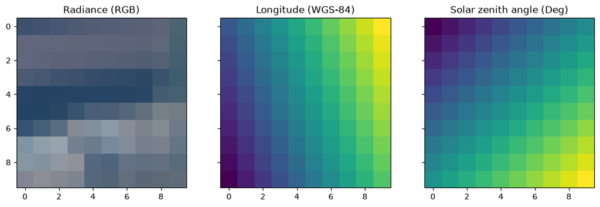

The input image doesn't look like much because this is just a 10x10 pixel example. However we see per-pixel spectral variation in the radiance RGBs, and systematic variation in the location and geometric variables.

```python
# Load the output files
rfl_path = env.path("examples", "image_cube", "small", "output", "ang20170323t202244_rfl")
state_path = env.path("examples", "image_cube", "small", "output", "ang20170323t202244_state")
uncert_path = env.path("examples", "image_cube", "small", "output", "ang20170323t202244_uncert")

rfl = envi.open(envi_header(str(rfl_path)))
state = envi.open(envi_header(str(state_path)))
uncert = envi.open(envi_header(str(uncert_path)))

rfl_im = rfl.open_memmap(interleave='bip')
state_im = state.open_memmap(interleave='bip')
uncert_im = uncert.open_memmap(interleave='bip')

print(f'Shape of the _rfl file: {rfl_im.shape}')
print(f'Shape of the _state file: {state_im.shape}')
print(f'Shape of the _uncert file: {uncert_im.shape}')
```

# Load the output files rfl_path = env.path("examples", "image_cube", "small", "output", "ang20170323t202244_rfl") state_path = env.path("examples", "image_cube", "small", "output", "ang20170323t202244_state") uncert_path = env.path("examples", "image_cube", "small", "output", "ang20170323t202244_uncert") rfl = envi.open(envi_header(str(rfl_path))) state = envi.open(envi_header(str(state_path))) uncert = envi.open(envi_header(str(uncert_path))) rfl_im = rfl.open_memmap(interleave='bip') state_im = state.open_memmap(interleave='bip') uncert_im = uncert.open_memmap(interleave='bip') print(f'Shape of the _rfl file: {rfl_im.shape}') print(f'Shape of the _state file: {state_im.shape}') print(f'Shape of the _uncert file: {uncert_im.shape}')

```
Shape of the _rfl file: (10, 10, 425)
Shape of the _state file: (10, 10, 427)
Shape of the _uncert file: (10, 10, 427)
```

The difference between the `_rfl` file and the `_state` file is that the `_rfl` file only contains the solutions for surface reflectance variables. Here, the AVIRIS-NG image contains 425 wavelength bands. As a result, the `_rfl` contains 425 bands. The `_state` and `_uncert` files contain the surface reflectance solutions and uncertainty calculated as the standard deviation of the posterior distributions for the 425 wavelength bands and for non-reflectance statevector elements; here, aerosol optical depth (AOD) and water vapor (H2O).

```python
# Plot the output data
normalize = lambda x, vmin, vmax:  (x - vmin) / (vmax - vmin)
bands = [55, 35, 15]

fig, axs = plt.subplots(2, 2, sharex=True, sharey=True, figsize=(8, 8))
axs = np.ravel(axs)
plot = axs[0].imshow(normalize(rfl_im[..., bands], 0, 0.3))
uncert = axs[1].imshow(uncert_im[..., 55])
aod = axs[2].imshow(state_im[..., -2])
h2o = axs[3].imshow(state_im[..., -1])

plt.colorbar(uncert)
plt.colorbar(aod)
plt.colorbar(h2o)

title = axs[0].set_title('Reflectance')
title = axs[1].set_title('Uncertainty (at 650 nm)')
title = axs[2].set_title('AOD')
title = axs[3].set_title('H2O')
```

# Plot the output data normalize = lambda x, vmin, vmax: (x - vmin) / (vmax - vmin) bands = [55, 35, 15] fig, axs = plt.subplots(2, 2, sharex=True, sharey=True, figsize=(8, 8)) axs = np.ravel(axs) plot = axs[0].imshow(normalize(rfl_im[..., bands], 0, 0.3)) uncert = axs[1].imshow(uncert_im[..., 55]) aod = axs[2].imshow(state_im[..., -2]) h2o = axs[3].imshow(state_im[..., -1]) plt.colorbar(uncert) plt.colorbar(aod) plt.colorbar(h2o) title = axs[0].set_title('Reflectance') title = axs[1].set_title('Uncertainty (at 650 nm)') title = axs[2].set_title('AOD') title = axs[3].set_title('H2O')

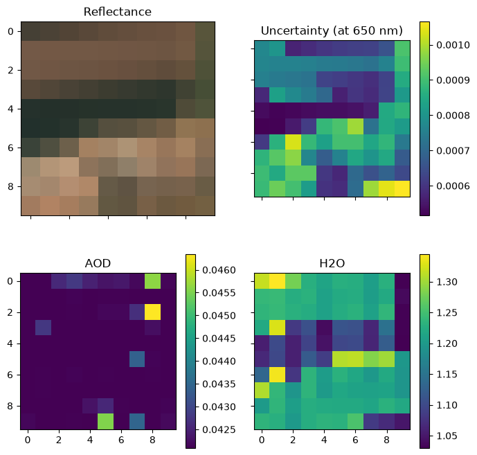

## The Analytical Line

In the example above, we ran Isofit using the full optimal estimation (OE) on each pixel independently. Computationally, this amounts to iterating through each row-column pair to solve for the full state-vector (427 variables in the above case). However for large images, this demands long run-times, and ignores the principle that some state-vector elements, namely the atmospheric variables like AOD and H2O, should not vary from one pixel to another, but rather should be spatially smooth, and only vary over multi-pixel length scales [Link to the relevent paper](https://www.sciencedirect.com/science/article/pii/S0034425723004534/).

The analytical line and empirical line algorithms leverage the assumption of a spatially smooth atmosphere to decrease run times by a factor of 10. Currently, we suggest using the analytical line algorithm and not the empirical line algorithm.

See the following CLI call to run Apply OE with the analytical line algorithm:

```
  IC=$(isofit path examples)/image_cube/medium EX=$(isofit path examples)/image_cube/medium \
  isofit apply_oe \
  $IC/ang20170323t202244_rdn_7k-8k \
  $IC/ang20170323t202244_loc_7k-8k \
  $IC/ang20170323t202244_obs_7k-8k \
  $EX \
  ang \
  --surface_path $EX/configs/surface.json \
  --emulator_base $(isofit path srtmnet --key file) \
  --n_cores 10 \
  --presolve \
  --analytical_line \
  --segmentation_size 50 \
  --log_file $EX/log.txt
```

Most of the input parameters are identical to the per-pixel application above. However, we've added a `--log_file`, the `--analytical_line` flag, and a `--segmentation_size`. The `--log_file` points the program to write a text file to print logging statements during run time. The `--analytical_line` flag tells Isofit to use the analytical line algorithm.

A simple overview for the anylitical line algorithm:

1. All three input files are "segmented" into superpixel blocks using the SLIC algorithm. The `--segmentation_size` value sets the number of pixels that each superpixel contains.
2. At the superpixel resolution, Isofit solves for the OE solutions, which provides both surface and atmospheric state variables.
3. Atmospheric state variables are spatially interpolated to full image resolution. The spatial interpolation uses the Apply OE parameters `--num_neighbors` and `--atm_sigma`.
4. With a fixed atmosphere, we leverage a closed form solution for surface state elements that allows for a solution convergence in a single iteration.

```python
# Alternatively, you can programatically call apply_oe. If you executed apply_oe via the command line above, do not run this
# We use the env object to retrieve the actual location of the ISOFIT extra dependencies instead of assuming where they could be
import os
import shutil

from isofit.utils.apply_oe import apply_oe
from isofit.data import env

output = env.path("examples", "image_cube", "medium")

# Cleanup any previous runs; comment this out if you want to preserve a previous run's output
if (o := output / "output").exists():
    shutil.rmtree(o)

apply_oe(
    input_radiance    = str(env.path("examples", "image_cube", "medium", "data", "ang20170323t202244_rdn_7k-8k")),
    input_loc         = str(env.path("examples", "image_cube", "medium", "data", "ang20170323t202244_loc_7k-8k")),
    input_obs         = str(env.path("examples", "image_cube", "medium", "data", "ang20170323t202244_obs_7k-8k")),
    working_directory = str(output),
    sensor            = "ang",
    surface_path      = str(env.path("examples", "image_cube", "medium", "configs", "surface.json")),
    emulator_base     = str(env.path("srtmnet", key="srtmnet.file")),
    presolve          = True,
    n_cores           = os.cpu_count(),
    analytical_line   = True,
    segmentation_size = 50,
)
```

# Alternatively, you can programatically call apply_oe. If you executed apply_oe via the command line above, do not run this # We use the env object to retrieve the actual location of the ISOFIT extra dependencies instead of assuming where they could be import os import shutil from isofit.utils.apply_oe import apply_oe from isofit.data import env output = env.path("examples", "image_cube", "medium") # Cleanup any previous runs; comment this out if you want to preserve a previous run's output if (o := output / "output").exists(): shutil.rmtree(o) apply_oe( input_radiance = str(env.path("examples", "image_cube", "medium", "data", "ang20170323t202244_rdn_7k-8k")), input_loc = str(env.path("examples", "image_cube", "medium", "data", "ang20170323t202244_loc_7k-8k")), input_obs = str(env.path("examples", "image_cube", "medium", "data", "ang20170323t202244_obs_7k-8k")), working_directory = str(output), sensor = "ang", surface_path = str(env.path("examples", "image_cube", "medium", "configs", "surface.json")), emulator_base = str(env.path("srtmnet", key="srtmnet.file")), presolve = True, n_cores = os.cpu_count(), analytical_line = True, segmentation_size = 50, )

```
INFO:2026-07-28,01:48:38 || apply_oe.py:apply_oe() | Checking input data files...
```

```
INFO:2026-07-28,01:48:38 || apply_oe.py:apply_oe() | ...Data file checks complete
```

```
INFO:2026-07-28,01:48:38 || apply_oe.py:apply_oe() | Setting up files and directories....
```

```
INFO:2026-07-28,01:48:38 || template_construction.py:__init__() | Flightline ID: ang20170323t202244
```

```
INFO:2026-07-28,01:48:38 || template_construction.py:__init__() | no noise path found, proceeding without
```

```
INFO:2026-07-28,01:48:38 || apply_oe.py:apply_oe() | ...file/directory setup complete
```

```
INFO:2026-07-28,01:48:38 || apply_oe.py:apply_oe() | Using inversion windows: [[350.0, 1360.0], [1410, 1800.0], [1970.0, 2500.0]]
```

```
INFO:2026-07-28,01:48:38 || template_construction.py:get_wavelengths() | No wavelength file provided. Obtaining wavelength grid from ENVI header of radiance cube.
```

```
INFO:2026-07-28,01:48:38 || template_construction.py:get_wavelengths() | Wavelength units of nm inferred...converting to microns
```

```
INFO:2026-07-28,01:48:38 || template_construction.py:check_surface_model() | No surface model provided. Build new one using given config file.
```

```
0 ['/home/runner/work/isofit-tutorials/data/reflectance/surface_model_ucsb']
```

```
1 ['/home/runner/work/isofit-tutorials/data/reflectance/surface_model_ucsb']
```

```
2 ['/home/runner/work/isofit-tutorials/data/reflectance/surface_model_ucsb']
```

```
3 ['/home/runner/work/isofit-tutorials/data/reflectance/surface_model_ucsb']
```

```
4 ['/home/runner/work/isofit-tutorials/data/reflectance/surface_model_ucsb']
```

```
5 ['/home/runner/work/isofit-tutorials/data/reflectance/surface_model_ucsb']
```

```
6 ['/home/runner/work/isofit-tutorials/data/reflectance/surface_model_ucsb']
7 ['/home/runner/work/isofit-tutorials/data/reflectance/surface_model_ucsb']
```

```
INFO:2026-07-28,01:48:41 || apply_oe.py:apply_oe() | Observation means:
```

```
INFO:2026-07-28,01:48:41 || apply_oe.py:apply_oe() | Path (km): 20.427719754829514
```

```
INFO:2026-07-28,01:48:41 || apply_oe.py:apply_oe() | To-sensor azimuth (deg): 70.76934723658717
```

```
INFO:2026-07-28,01:48:41 || apply_oe.py:apply_oe() | To-sensor zenith (deg): 14.66271150290934
```

```
INFO:2026-07-28,01:48:41 || apply_oe.py:apply_oe() | To-sun azimuth (deg): 197.26038313891075
```

```
INFO:2026-07-28,01:48:41 || apply_oe.py:apply_oe() | To-sun zenith (deg): 32.53545303568223
```

```
INFO:2026-07-28,01:48:41 || apply_oe.py:apply_oe() | Relative to-sun azimuth (deg): 126.4910359023236
```

```
INFO:2026-07-28,01:48:41 || apply_oe.py:apply_oe() | Altitude (km): 19.82240248090924
```

```
INFO:2026-07-28,01:48:41 || apply_oe.py:apply_oe() | Segmenting...
```

```
2026-07-28 01:48:44,980	INFO worker.py:2024 -- Started a local Ray instance.
```

```
(segment_chunk pid=4884) INFO:2026-07-28,01:48:47 ||| 768: starting
```

```
(segment_chunk pid=4884) INFO:2026-07-28,01:48:48 ||| 768: completing
INFO:2026-07-28,01:48:48 || apply_oe.py:apply_oe() | Extracting /home/runner/work/isofit-tutorials/isofit-tutorials/image_cube/medium/input/ang20170323t202244_subs_rdn
```

```
2026-07-28 01:48:48,670	INFO worker.py:1847 -- Calling ray.init() again after it has already been called.
```

```
INFO:2026-07-28,01:48:51 || apply_oe.py:apply_oe() | Extracting /home/runner/work/isofit-tutorials/isofit-tutorials/image_cube/medium/input/ang20170323t202244_subs_obs
```

```
2026-07-28 01:48:51,492	INFO worker.py:1847 -- Calling ray.init() again after it has already been called.
```

```
INFO:2026-07-28,01:48:51 || apply_oe.py:apply_oe() | Extracting /home/runner/work/isofit-tutorials/isofit-tutorials/image_cube/medium/input/ang20170323t202244_subs_loc
```

```
2026-07-28 01:48:51,590	INFO worker.py:1847 -- Calling ray.init() again after it has already been called.
```

```
INFO:2026-07-28,01:48:51 || apply_oe.py:apply_oe() | Skipping None, because is not a path.
```

```
INFO:2026-07-28,01:48:51 || apply_oe.py:apply_oe() | Skipping None, because is not a path.
```

```
INFO:2026-07-28,01:48:51 || apply_oe.py:apply_oe() | Pre-solve H2O grid: [0.2  0.76 1.32 1.88 2.44 2.99 3.55 4.11 4.67 5.23]
```

```
INFO:2026-07-28,01:48:51 || apply_oe.py:apply_oe() | Writing H2O pre-solve configuration file.
```

```
INFO:2026-07-28,01:48:51 || ini.py:toTemplate() | Saved converted json to: /home/runner/work/isofit-tutorials/isofit-tutorials/image_cube/medium/config/ang20170323t202244_h2o.json.tmpl
```

```
INFO:2026-07-28,01:48:51 || apply_oe.py:apply_oe() | Run ISOFIT initial guess
```

```
WARNING:2026-07-28,01:48:51 || __init__.py:checkNumThreads() |
! Number of threads is greater than 1 (currently: 4), this may greatly impact performance
! Please set this the environment variables 'MKL_NUM_THREADS' and 'OMP_NUM_THREADS' to '1'
```

```
INFO:2026-07-28,01:48:51 || configs.py:create_new_config() | Loading config file: /home/runner/work/isofit-tutorials/isofit-tutorials/image_cube/medium/config/ang20170323t202244_h2o.json
```

```
INFO:2026-07-28,01:48:51 || configs.py:get_config_errors() | Checking config sections for configuration issues
```

```
INFO:2026-07-28,01:48:51 || configs.py:get_config_errors() | Configuration file checks complete, no errors found.
```

```
2026-07-28 01:48:51,895	INFO worker.py:1847 -- Calling ray.init() again after it has already been called.
```

```
INFO:2026-07-28,01:48:51 || isofit.py:run() | Running surfaces: uniform_surface
```

```
INFO:2026-07-28,01:48:51 || atmosphere.py:__init__() | Loading from wavelength_file: /home/runner/work/isofit-tutorials/isofit-tutorials/image_cube/medium/data/wavelengths.txt
```

```
INFO:2026-07-28,01:48:51 || reader.py:__init__() | No LUT provided, attempting to build it
```

```
INFO:2026-07-28,01:48:51 || zarr.py:calc_shards() | Number of points: 4,250
```

```
INFO:2026-07-28,01:48:51 || zarr.py:calc_shards() | Target chunks per file: 157903 (6.00gb) (scale: 12)
```

```
INFO:2026-07-28,01:48:51 || zarr.py:calc_shards() | Shapes:
```

```
INFO:2026-07-28,01:48:51 || zarr.py:calc_shards() |   dimensions: [425  10]
```

```
INFO:2026-07-28,01:48:51 || zarr.py:calc_shards() |     chunking: [425   1]
```

```
INFO:2026-07-28,01:48:51 || zarr.py:calc_shards() | Recommended
```

```
INFO:2026-07-28,01:48:51 || zarr.py:calc_shards() |     sharding: [425  10]
```

```
INFO:2026-07-28,01:48:51 || zarr.py:calc_shards() | Produces:
```

```
INFO:2026-07-28,01:48:51 || zarr.py:calc_shards() |   Chunks per file: 10 (0.00gb)
```

```
INFO:2026-07-28,01:48:51 || zarr.py:calc_shards() |   Number of files: 1
```

```
INFO:2026-07-28,01:48:51 || writer.py:runSimulations() | Running any pre-sim functions
```

```
INFO:2026-07-28,01:48:51 || sRTMnet.py:preSim() | Building simulator and executing (6S)
```

```
INFO:2026-07-28,01:48:51 || reader.py:__init__() | No LUT provided, attempting to build it
```

```
INFO:2026-07-28,01:48:51 || zarr.py:calc_shards() | Number of points: 8,610
```

```
INFO:2026-07-28,01:48:51 || zarr.py:calc_shards() | Target chunks per file: 77942 (6.00gb) (scale: 12)
```

```
INFO:2026-07-28,01:48:51 || zarr.py:calc_shards() | Shapes:
```

```
INFO:2026-07-28,01:48:51 || zarr.py:calc_shards() |   dimensions: [861  10]
```

```
INFO:2026-07-28,01:48:51 || zarr.py:calc_shards() |     chunking: [861   1]
```

```
INFO:2026-07-28,01:48:51 || zarr.py:calc_shards() | Recommended
```

```
INFO:2026-07-28,01:48:51 || zarr.py:calc_shards() |     sharding: [861   2]
```

```
INFO:2026-07-28,01:48:51 || zarr.py:calc_shards() | Produces:
```

```
INFO:2026-07-28,01:48:51 || zarr.py:calc_shards() |   Chunks per file: 2 (0.00gb)
```

```
INFO:2026-07-28,01:48:51 || zarr.py:calc_shards() |   Number of files: 5
```

```
INFO:2026-07-28,01:48:52 || writer.py:runSimulations() | Running any pre-sim functions
```

```
INFO:2026-07-28,01:48:52 || writer.py:runSimulations() | Executing parallel simulations by shards
```

```
(shardWriter pid=4885) INFO:2026-07-28,01:48:52 ||| Starting shard (np.int64(0),)
```

```
(shardWriter pid=4887) INFO:2026-07-28,01:48:59 ||| Finished points (np.int64(1),), flushing to disk
(extract_chunk pid=4884) INFO:2026-07-28,01:48:51 ||| 768: starting [repeated 15x across cluster]
(segment_chunk pid=4886) INFO:2026-07-28,01:48:48 ||| 512: completing [repeated 3x across cluster]
(shardWriter pid=4884) INFO:2026-07-28,01:48:52 ||| Starting shard (np.int64(3),) [repeated 3x across cluster]
INFO:2026-07-28,01:48:59 || writer.py:parallelize_shards() | Saved chunkless: {'solzen', 'coszen'}
```

```
INFO:2026-07-28,01:48:59 || common.py:__call__() |  20.00% shards complete (elapsed: 0:00:07.200745, rate: 0:00:01.440149, eta: 0:11:52.873755)
```

```
INFO:2026-07-28,01:48:59 || common.py:__call__() |  40.00% shards complete (elapsed: 0:00:07.217314, rate: 0:00:01.443463, eta: 0:05:53.648386)
```

```
INFO:2026-07-28,01:48:59 || common.py:__call__() |  60.00% shards complete (elapsed: 0:00:07.244546, rate: 0:00:01.448909, eta: 0:03:54.240321)
```

```
INFO:2026-07-28,01:48:59 || common.py:__call__() |  80.00% shards complete (elapsed: 0:00:07.284539, rate: 0:00:01.456908, eta: 0:02:54.828936)
```

```
(shardWriter pid=4885) INFO:2026-07-28,01:48:59 ||| Finished shard (np.int64(0),)
```

```
INFO:2026-07-28,01:49:03 || common.py:__call__() | 100.00% shards complete (elapsed: 0:00:11.119205, rate: 0:00:02.223841, eta: 0:03:31.264895)
```

```
INFO:2026-07-28,01:49:03 || writer.py:runSimulations() | Running any post-sim functions
```

```
INFO:2026-07-28,01:49:03 || writer.py:runSimulations() | Saving post-sim data to index zero of all dimensions except wl
```

```
INFO:2026-07-28,01:49:04 || sRTMnet.py:process() | Loading and predicting with emulator on 4 cores
```

```
INFO:2026-07-28,01:49:04 || common.py:__call__() | 100.00% shards processed (elapsed: 0:00:00.863706, rate: 0:00:00.863706, eta: 0:01:25.506894)
```

```
INFO:2026-07-28,01:49:04 || writer.py:runSimulations() | Saving pre-sim data to index zero of all dimensions except wl
```

```
INFO:2026-07-28,01:49:05 || writer.py:runSimulations() | Running any post-sim functions
```

```
INFO:2026-07-28,01:49:05 || isofit.py:run() | Beginning 1998 inversions in 40 chunks using 4 cores
```

[output not shown]

```
(Worker pid=5200) INFO:2026-07-28,01:49:13 ||| Worker 3 completed 1/~499.0:: 0.2% complete
```

[output not shown]

```
(Worker pid=5197) INFO:2026-07-28,01:49:33 ||| Worker at start location (152,0) completed 50/51
(Worker pid=5199) INFO:2026-07-28,01:49:28 ||| Worker 2 completed 52/~499.0:: 10.42% complete
```

```
(Worker pid=5197) INFO:2026-07-28,01:49:34 ||| Worker 1 completed 52/~499.0:: 10.42% complete
```

```
(Worker pid=5198) INFO:2026-07-28,01:49:34 ||| Worker at start location (203,0) completed 50/51
```

```
(Worker pid=5200) INFO:2026-07-28,01:49:35 ||| Worker 3 completed 52/~499.0:: 10.42% complete [repeated 2x across cluster]
(Worker pid=5199) INFO:2026-07-28,01:49:56 ||| Worker at start location (255,0) completed 51/52 [repeated 2x across cluster]
```

```
(Worker pid=5200) INFO:2026-07-28,01:50:00 ||| Worker 3 completed 103/~499.0:: 20.64% complete [repeated 2x across cluster]
(Worker pid=5197) INFO:2026-07-28,01:50:04 ||| Worker at start location (306,0) completed 50/51 [repeated 2x across cluster]
```

```
(Worker pid=5198) INFO:2026-07-28,01:50:07 ||| Worker 0 completed 103/~499.0:: 20.64% complete [repeated 2x across cluster]
(Worker pid=5199) INFO:2026-07-28,01:50:15 ||| Worker at start location (460,0) completed 51/52 [repeated 2x across cluster]
```

```
(Worker pid=5199) INFO:2026-07-28,01:50:16 ||| Worker 2 completed 156/~499.0:: 31.26% complete
(Worker pid=5200) INFO:2026-07-28,01:50:20 ||| Worker at start location (511,0) completed 50/51
```

```
(Worker pid=5200) INFO:2026-07-28,01:50:20 ||| Worker 3 completed 154/~499.0:: 30.86% complete
```

```
(Worker pid=5198) INFO:2026-07-28,01:50:23 ||| Worker at start location (613,0) completed 50/51
```

```
(Worker pid=5198) INFO:2026-07-28,01:50:23 ||| Worker 0 completed 154/~499.0:: 30.86% complete
```

```
(Worker pid=5199) INFO:2026-07-28,01:50:27 ||| Worker 2 completed 208/~499.0:: 41.68% complete
```

```
(Worker pid=5197) INFO:2026-07-28,01:50:29 ||| Worker at start location (562,0) completed 50/51 [repeated 2x across cluster]
```

```
(Worker pid=5198) INFO:2026-07-28,01:50:31 ||| Worker 0 completed 205/~499.0:: 41.08% complete [repeated 3x across cluster]
(Worker pid=5199) INFO:2026-07-28,01:50:36 ||| Worker at start location (818,0) completed 50/51 [repeated 3x across cluster]
```

```
(Worker pid=5198) INFO:2026-07-28,01:50:41 ||| Worker 0 completed 256/~499.0:: 51.3% complete [repeated 4x across cluster]
(Worker pid=5199) INFO:2026-07-28,01:50:45 ||| Worker at start location (1023,0) completed 50/51 [repeated 4x across cluster]
```

```
(Worker pid=5198) INFO:2026-07-28,01:50:50 ||| Worker 0 completed 307/~499.0:: 61.52% complete [repeated 4x across cluster]
(Worker pid=5199) INFO:2026-07-28,01:50:55 ||| Worker at start location (1228,0) completed 50/51 [repeated 4x across cluster]
```

```
(Worker pid=5198) INFO:2026-07-28,01:50:58 ||| Worker 0 completed 358/~499.0:: 71.74% complete [repeated 4x across cluster]
(Worker pid=5199) INFO:2026-07-28,01:51:03 ||| Worker at start location (1433,0) completed 50/51 [repeated 4x across cluster]
```

```
(Worker pid=5198) INFO:2026-07-28,01:51:08 ||| Worker 0 completed 410/~499.0:: 82.16% complete [repeated 4x across cluster]
(Worker pid=5199) INFO:2026-07-28,01:51:12 ||| Worker at start location (1638,0) completed 50/51 [repeated 4x across cluster]
```

```
(Worker pid=5198) INFO:2026-07-28,01:51:17 ||| Worker 0 completed 462/~499.0:: 92.59% complete [repeated 4x across cluster]
(Worker pid=5199) INFO:2026-07-28,01:51:22 ||| Worker at start location (1843,0) completed 50/51 [repeated 4x across cluster]
```

```
INFO:2026-07-28,01:51:24 || isofit.py:run() | Pixel class: uniform_surface inversions complete.
```

```
INFO:2026-07-28,01:51:24 || isofit.py:run() | Running totals
```

```
INFO:2026-07-28,01:51:24 || isofit.py:run() | 139.24s total
```

```
INFO:2026-07-28,01:51:24 || isofit.py:run() | 14.3497 spectra/s
```

```
INFO:2026-07-28,01:51:24 || isofit.py:run() | 3.5874 spectra/s/core
```

```
INFO:2026-07-28,01:51:24 || isofit.py:run() | All Inversions complete.
```

```
INFO:2026-07-28,01:51:24 || isofit.py:run() | Final totals
```

```
INFO:2026-07-28,01:51:24 || isofit.py:run() | 139.24s total
```

```
INFO:2026-07-28,01:51:24 || isofit.py:run() | 14.3497 spectra/s
```

```
INFO:2026-07-28,01:51:24 || isofit.py:run() | 3.5874 spectra/s/core
```

```
INFO:2026-07-28,01:51:24 || apply_oe.py:apply_oe() | Full (non-aerosol) LUTs:
```

```
INFO:2026-07-28,01:51:25 || apply_oe.py:apply_oe() | Elevation: None
```

```
INFO:2026-07-28,01:51:25 || apply_oe.py:apply_oe() | To-sensor zenith: [11.5786 17.7236]
```

```
INFO:2026-07-28,01:51:25 || apply_oe.py:apply_oe() | To-sun zenith: None
```

```
INFO:2026-07-28,01:51:25 || apply_oe.py:apply_oe() | Relative to-sun azimuth: None
```

```
INFO:2026-07-28,01:51:25 || apply_oe.py:apply_oe() | H2O Vapor: [1.0155 1.2241 1.4328]
```

```
INFO:2026-07-28,01:51:25 || apply_oe.py:apply_oe() | Writing main configuration file.
```

```
INFO:2026-07-28,01:51:25 || template_construction.py:load_climatology() | Loading Climatology
```

```
INFO:2026-07-28,01:51:25 || template_construction.py:load_climatology() | Climatology Loaded.  Aerosol State Vector:
{'AOT550': {'bounds': [0.04209, 1.0], 'scale': 1, 'init': 0.137881, 'prior_sigma': 0.1, 'prior_mean': 0.137881}}
Aerosol LUT Grid:
{'AOT550': [0.04209, 0.137881, 0.233672, 0.329463, 0.425254, 0.521045, 0.6168359999999999, 0.712627, 0.808418, 0.9042089999999999, 1.0]}
Aerosol model path:/home/runner/work/isofit-tutorials/data/aerosol_model.txt
```

```
INFO:2026-07-28,01:51:25 || ini.py:toTemplate() | Saved converted json to: /home/runner/work/isofit-tutorials/isofit-tutorials/image_cube/medium/config/ang20170323t202244_isofit.json.tmpl
```

```
INFO:2026-07-28,01:51:25 || apply_oe.py:apply_oe() | Running ISOFIT with full LUT
```

```
WARNING:2026-07-28,01:51:25 || __init__.py:checkNumThreads() |
! Number of threads is greater than 1 (currently: 4), this may greatly impact performance
! Please set this the environment variables 'MKL_NUM_THREADS' and 'OMP_NUM_THREADS' to '1'
```

```
INFO:2026-07-28,01:51:25 || configs.py:create_new_config() | Loading config file: /home/runner/work/isofit-tutorials/isofit-tutorials/image_cube/medium/config/ang20170323t202244_isofit.json
```

```
INFO:2026-07-28,01:51:25 || configs.py:get_config_errors() | Checking config sections for configuration issues
```

```
INFO:2026-07-28,01:51:25 || configs.py:get_config_errors() | Configuration file checks complete, no errors found.
```

```
2026-07-28 01:51:25,357	INFO worker.py:1847 -- Calling ray.init() again after it has already been called.
```

```
INFO:2026-07-28,01:51:25 || isofit.py:run() | Running surfaces: uniform_surface
```

```
INFO:2026-07-28,01:51:25 || atmosphere.py:__init__() | Loading from wavelength_file: /home/runner/work/isofit-tutorials/isofit-tutorials/image_cube/medium/data/wavelengths.txt
```

```
INFO:2026-07-28,01:51:25 || reader.py:__init__() | No LUT provided, attempting to build it
```

```
INFO:2026-07-28,01:51:25 || zarr.py:calc_shards() | Number of points: 28,050
```

```
INFO:2026-07-28,01:51:25 || zarr.py:calc_shards() | Target chunks per file: 157903 (6.00gb) (scale: 12)
```

```
INFO:2026-07-28,01:51:25 || zarr.py:calc_shards() | Shapes:
```

```
INFO:2026-07-28,01:51:25 || zarr.py:calc_shards() |   dimensions: [425  11   3   2]
```

```
INFO:2026-07-28,01:51:25 || zarr.py:calc_shards() |     chunking: [425   1   1   1]
```

```
INFO:2026-07-28,01:51:25 || zarr.py:calc_shards() | Recommended
```

```
INFO:2026-07-28,01:51:25 || zarr.py:calc_shards() |     sharding: [425  11   3   2]
```

```
INFO:2026-07-28,01:51:25 || zarr.py:calc_shards() | Produces:
```

```
INFO:2026-07-28,01:51:25 || zarr.py:calc_shards() |   Chunks per file: 66 (0.00gb)
```

```
INFO:2026-07-28,01:51:25 || zarr.py:calc_shards() |   Number of files: 1
```

```
INFO:2026-07-28,01:51:25 || writer.py:runSimulations() | Running any pre-sim functions
```

```
INFO:2026-07-28,01:51:25 || sRTMnet.py:preSim() | Building simulator and executing (6S)
```

```
INFO:2026-07-28,01:51:25 || reader.py:__init__() | No LUT provided, attempting to build it
```

```
INFO:2026-07-28,01:51:25 || zarr.py:calc_shards() | Number of points: 56,826
```

```
INFO:2026-07-28,01:51:25 || zarr.py:calc_shards() | Target chunks per file: 77942 (6.00gb) (scale: 12)
```

```
INFO:2026-07-28,01:51:25 || zarr.py:calc_shards() | Shapes:
```

```
INFO:2026-07-28,01:51:25 || zarr.py:calc_shards() |   dimensions: [861  11   3   2]
```

```
INFO:2026-07-28,01:51:25 || zarr.py:calc_shards() |     chunking: [861   1   1   1]
```

```
INFO:2026-07-28,01:51:25 || zarr.py:calc_shards() | Recommended
```

```
INFO:2026-07-28,01:51:25 || zarr.py:calc_shards() |     sharding: [861  11   1   2]
```

```
INFO:2026-07-28,01:51:25 || zarr.py:calc_shards() | Produces:
```

```
INFO:2026-07-28,01:51:25 || zarr.py:calc_shards() |   Chunks per file: 22 (0.00gb)
```

```
INFO:2026-07-28,01:51:25 || zarr.py:calc_shards() |   Number of files: 3
```

```
INFO:2026-07-28,01:51:25 || writer.py:runSimulations() | Running any pre-sim functions
```

```
INFO:2026-07-28,01:51:25 || writer.py:runSimulations() | Executing parallel simulations by shards
```

```
INFO:2026-07-28,01:52:30 || writer.py:parallelize_shards() | Saved chunkless: {'solzen', 'coszen'}
```

```
INFO:2026-07-28,01:52:30 || common.py:__call__() |  33.33% shards complete (elapsed: 0:01:04.692494, rate: 0:00:21.564165, eta: 1:46:44.556906)
```

```
INFO:2026-07-28,01:52:42 || common.py:__call__() |  66.67% shards complete (elapsed: 0:01:16.513612, rate: 0:00:25.504537, eta: 1:02:29.166988)
```

```
INFO:2026-07-28,01:52:42 || common.py:__call__() | 100.00% shards complete (elapsed: 0:01:16.609481, rate: 0:00:25.536494, eta: 0:41:17.039886)
```

```
INFO:2026-07-28,01:52:42 || writer.py:runSimulations() | Running any post-sim functions
```

```
INFO:2026-07-28,01:52:42 || writer.py:runSimulations() | Saving post-sim data to index zero of all dimensions except wl
```

```
INFO:2026-07-28,01:52:43 || sRTMnet.py:process() | Loading and predicting with emulator on 4 cores
```

```
INFO:2026-07-28,01:52:44 || common.py:__call__() | 100.00% shards processed (elapsed: 0:00:01.319522, rate: 0:00:01.319522, eta: 0:02:10.632678)
```

```
INFO:2026-07-28,01:52:44 || writer.py:runSimulations() | Saving pre-sim data to index zero of all dimensions except wl
```

```
INFO:2026-07-28,01:52:45 || writer.py:runSimulations() | Running any post-sim functions
```

```
INFO:2026-07-28,01:52:45 || isofit.py:run() | Beginning 1998 inversions in 40 chunks using 4 cores
```

[output not shown]

```
(Worker pid=5349) INFO:2026-07-28,01:52:53 ||| Worker 0 completed 1/~499.0:: 0.2% complete
```

[output not shown]

```
(Worker pid=5349) INFO:2026-07-28,01:53:19 ||| Worker at start location (203,0) completed 50/51
```

```
(Worker pid=5349) INFO:2026-07-28,01:53:19 ||| Worker 0 completed 52/~499.0:: 10.42% complete [repeated 2x across cluster]
```

```
(Worker pid=5831) INFO:2026-07-28,01:53:25 ||| Worker at start location (50,0) completed 50/51 [repeated 2x across cluster]
```

```
(Worker pid=5831) INFO:2026-07-28,01:53:26 ||| Worker 3 completed 52/~499.0:: 10.42% complete [repeated 2x across cluster]
```

```
(Worker pid=5832) INFO:2026-07-28,01:53:51 ||| Worker at start location (255,0) completed 51/52
```

```
(Worker pid=5832) INFO:2026-07-28,01:53:51 ||| Worker 2 completed 104/~499.0:: 20.84% complete
```

```
(Worker pid=5831) INFO:2026-07-28,01:53:57 ||| Worker at start location (408,0) completed 50/51
```

```
(Worker pid=5831) INFO:2026-07-28,01:53:57 ||| Worker 3 completed 103/~499.0:: 20.64% complete
```

```
(Worker pid=5832) INFO:2026-07-28,01:54:17 ||| Worker at start location (460,0) completed 51/52 [repeated 3x across cluster]
(Worker pid=5833) INFO:2026-07-28,01:54:00 ||| Worker 1 completed 103/~499.0:: 20.64% complete [repeated 2x across cluster]
```

```
(Worker pid=5833) INFO:2026-07-28,01:54:23 ||| Worker at start location (613,0) completed 50/51
(Worker pid=5832) INFO:2026-07-28,01:54:18 ||| Worker 2 completed 156/~499.0:: 31.26% complete
```

```
(Worker pid=5833) INFO:2026-07-28,01:54:23 ||| Worker 1 completed 154/~499.0:: 30.86% complete
```

```
(Worker pid=5831) INFO:2026-07-28,01:54:25 ||| Worker at start location (511,0) completed 50/51
```

```
(Worker pid=5831) INFO:2026-07-28,01:54:25 ||| Worker 3 completed 154/~499.0:: 30.86% complete
```

```
(Worker pid=5349) INFO:2026-07-28,01:54:29 ||| Worker 0 completed 154/~499.0:: 30.86% complete
```

```
(Worker pid=5832) INFO:2026-07-28,01:54:35 ||| Worker at start location (665,0) completed 51/52 [repeated 2x across cluster]
```

```
(Worker pid=5832) INFO:2026-07-28,01:54:35 ||| Worker 2 completed 208/~499.0:: 41.68% complete
```

```
(Worker pid=5831) INFO:2026-07-28,01:54:40 ||| Worker at start location (767,0) completed 50/51 [repeated 2x across cluster]
```

```
(Worker pid=5831) INFO:2026-07-28,01:54:41 ||| Worker 3 completed 205/~499.0:: 41.08% complete [repeated 2x across cluster]
```

```
(Worker pid=5832) INFO:2026-07-28,01:54:50 ||| Worker at start location (869,0) completed 50/51 [repeated 2x across cluster]
(Worker pid=5349) INFO:2026-07-28,01:54:44 ||| Worker 0 completed 205/~499.0:: 41.08% complete
```

```
(Worker pid=5832) INFO:2026-07-28,01:54:50 ||| Worker 2 completed 259/~499.0:: 51.9% complete
```

```
(Worker pid=5831) INFO:2026-07-28,01:54:56 ||| Worker at start location (972,0) completed 50/51 [repeated 2x across cluster]
(Worker pid=5833) INFO:2026-07-28,01:54:55 ||| Worker 1 completed 257/~499.0:: 51.5% complete
```

```
(Worker pid=5831) INFO:2026-07-28,01:54:56 ||| Worker 3 completed 256/~499.0:: 51.3% complete
```

```
(Worker pid=5832) INFO:2026-07-28,01:55:04 ||| Worker at start location (1074,0) completed 50/51 [repeated 2x across cluster]
(Worker pid=5349) INFO:2026-07-28,01:54:59 ||| Worker 0 completed 256/~499.0:: 51.3% complete
```

```
(Worker pid=5832) INFO:2026-07-28,01:55:05 ||| Worker 2 completed 310/~499.0:: 62.12% complete
```

```
(Worker pid=5831) INFO:2026-07-28,01:55:11 ||| Worker at start location (1177,0) completed 50/51 [repeated 2x across cluster]
(Worker pid=5833) INFO:2026-07-28,01:55:09 ||| Worker 1 completed 309/~499.0:: 61.92% complete
```

```
(Worker pid=5831) INFO:2026-07-28,01:55:11 ||| Worker 3 completed 307/~499.0:: 61.52% complete
```

```
(Worker pid=5832) INFO:2026-07-28,01:55:19 ||| Worker at start location (1279,0) completed 50/51 [repeated 2x across cluster]
(Worker pid=5349) INFO:2026-07-28,01:55:15 ||| Worker 0 completed 307/~499.0:: 61.52% complete
```

```
(Worker pid=5832) INFO:2026-07-28,01:55:19 ||| Worker 2 completed 361/~499.0:: 72.34% complete
```

```
(Worker pid=5831) INFO:2026-07-28,01:55:26 ||| Worker at start location (1382,0) completed 50/51 [repeated 2x across cluster]
(Worker pid=5833) INFO:2026-07-28,01:55:23 ||| Worker 1 completed 361/~499.0:: 72.34% complete
```

```
(Worker pid=5831) INFO:2026-07-28,01:55:26 ||| Worker 3 completed 358/~499.0:: 71.74% complete
```

```
(Worker pid=5832) INFO:2026-07-28,01:55:34 ||| Worker at start location (1484,0) completed 50/51 [repeated 2x across cluster]
(Worker pid=5349) INFO:2026-07-28,01:55:30 ||| Worker 0 completed 358/~499.0:: 71.74% complete
```

```
(Worker pid=5832) INFO:2026-07-28,01:55:34 ||| Worker 2 completed 412/~499.0:: 82.57% complete
```

```
(Worker pid=5831) INFO:2026-07-28,01:55:41 ||| Worker at start location (1587,0) completed 51/52 [repeated 2x across cluster]
(Worker pid=5833) INFO:2026-07-28,01:55:38 ||| Worker 1 completed 412/~499.0:: 82.57% complete
```

```
(Worker pid=5831) INFO:2026-07-28,01:55:41 ||| Worker 3 completed 410/~499.0:: 82.16% complete
```

```
(Worker pid=5832) INFO:2026-07-28,01:55:49 ||| Worker at start location (1689,0) completed 50/51 [repeated 2x across cluster]
(Worker pid=5349) INFO:2026-07-28,01:55:45 ||| Worker 0 completed 409/~499.0:: 81.96% complete
```

```
(Worker pid=5832) INFO:2026-07-28,01:55:50 ||| Worker 2 completed 463/~499.0:: 92.79% complete
```

```
(Worker pid=5831) INFO:2026-07-28,01:55:56 ||| Worker at start location (1792,0) completed 51/52 [repeated 2x across cluster]
(Worker pid=5833) INFO:2026-07-28,01:55:54 ||| Worker 1 completed 463/~499.0:: 92.79% complete
```

```
(Worker pid=5831) INFO:2026-07-28,01:55:57 ||| Worker 3 completed 462/~499.0:: 92.59% complete
```

```
(Worker pid=5832) INFO:2026-07-28,01:56:04 ||| Worker at start location (1894,0) completed 50/51 [repeated 2x across cluster]
```

```
INFO:2026-07-28,01:56:08 || isofit.py:run() | Pixel class: uniform_surface inversions complete.
```

```
INFO:2026-07-28,01:56:08 || isofit.py:run() | Running totals
```

```
INFO:2026-07-28,01:56:08 || isofit.py:run() | 203.27s total
```

```
INFO:2026-07-28,01:56:08 || isofit.py:run() | 9.8291 spectra/s
```

```
INFO:2026-07-28,01:56:08 || isofit.py:run() | 2.4573 spectra/s/core
```

```
INFO:2026-07-28,01:56:08 || isofit.py:run() | All Inversions complete.
```

```
INFO:2026-07-28,01:56:08 || isofit.py:run() | Final totals
```

```
INFO:2026-07-28,01:56:08 || isofit.py:run() | 203.27s total
```

```
INFO:2026-07-28,01:56:08 || isofit.py:run() | 9.8291 spectra/s
```

```
INFO:2026-07-28,01:56:08 || isofit.py:run() | 2.4573 spectra/s/core
```

```
INFO:2026-07-28,01:56:08 || apply_oe.py:apply_oe() | Analytical line inference
```

```
INFO:2026-07-28,01:56:08 || configs.py:create_new_config() | Loading config file: /home/runner/work/isofit-tutorials/isofit-tutorials/image_cube/medium/config/ang20170323t202244_isofit.json
```

```
2026-07-28 01:56:09,388	INFO worker.py:1847 -- Calling ray.init() again after it has already been called.
```

```
INFO:2026-07-28,01:56:09 || atm_interpolation.py:atm_interpolation() | Beginning atmospheric interpolation 4 cores
```

[output not shown]

[output cut: 97 more lines]

[output not shown]

[output cut: 134 more lines]

[output not shown]

[output cut: 130 more lines]

```
INFO:2026-07-28,01:56:18 || atm_interpolation.py:atm_interpolation() | Parallel atmospheric interpolations complete.  9.038964748382568 s total, 11063.213850667356 spectra/s, 2765.803462666839 spectra/s/core
```

```
2026-07-28 01:56:18,708	INFO worker.py:1847 -- Calling ray.init() again after it has already been called.
```

```
INFO:2026-07-28,01:56:18 || atmosphere.py:__init__() | Loading from wavelength_file: /home/runner/work/isofit-tutorials/isofit-tutorials/image_cube/medium/data/wavelengths.txt
```

```
INFO:2026-07-28,01:56:18 || reader.py:__init__() | Prebuilt LUT provided
```

[output not shown]

[output not shown]

```
(Worker pid=6242) INFO:2026-07-28,01:58:26 ||| Analytical line writing lines: 25 to 51. Surface: uniform_surface [repeated 2x across cluster]
```

```
(Worker pid=6228) INFO:2026-07-28,02:00:10 ||| Analytical line writing lines: 128 to 153. Surface: uniform_surface [repeated 2x across cluster]
```

```
(Worker pid=6241) INFO:2026-07-28,02:00:16 ||| Analytical line writing lines: 102 to 128. Surface: uniform_surface
```

```
(Worker pid=6243) INFO:2026-07-28,02:00:18 ||| Analytical line writing lines: 179 to 205. Surface: uniform_surface
```

```
(Worker pid=6228) INFO:2026-07-28,02:02:00 ||| Analytical line writing lines: 205 to 230. Surface: uniform_surface [repeated 2x across cluster]
```

```
(Worker pid=6243) INFO:2026-07-28,02:02:09 ||| Analytical line writing lines: 256 to 282. Surface: uniform_surface
```

```
(Worker pid=6242) INFO:2026-07-28,02:02:12 ||| Analytical line writing lines: 282 to 307. Surface: uniform_surface
```

```
(Worker pid=6243) INFO:2026-07-28,02:03:52 ||| Analytical line writing lines: 333 to 358. Surface: uniform_surface [repeated 2x across cluster]
```

```
(Worker pid=6242) INFO:2026-07-28,02:04:06 ||| Analytical line writing lines: 358 to 384. Surface: uniform_surface [repeated 2x across cluster]
```

```
(Worker pid=6243) INFO:2026-07-28,02:05:38 ||| Analytical line writing lines: 410 to 435. Surface: uniform_surface [repeated 2x across cluster]
```

```
(Worker pid=6228) INFO:2026-07-28,02:05:52 ||| Analytical line writing lines: 435 to 461. Surface: uniform_surface
```

```
(Worker pid=6241) INFO:2026-07-28,02:05:58 ||| Analytical line writing lines: 487 to 512. Surface: uniform_surface
```

```
(Worker pid=6243) INFO:2026-07-28,02:07:28 ||| Analytical line writing lines: 512 to 538. Surface: uniform_surface [repeated 2x across cluster]
```

```
(Worker pid=6228) INFO:2026-07-28,02:07:49 ||| Analytical line writing lines: 538 to 564. Surface: uniform_surface
```

```
(Worker pid=6241) INFO:2026-07-28,02:07:51 ||| Analytical line writing lines: 564 to 589. Surface: uniform_surface
```

```
(Worker pid=6242) INFO:2026-07-28,02:07:57 ||| Analytical line writing lines: 589 to 615. Surface: uniform_surface
```

```
(Worker pid=6243) INFO:2026-07-28,02:09:18 ||| Analytical line writing lines: 615 to 641. Surface: uniform_surface
```

```
(Worker pid=6228) INFO:2026-07-28,02:09:38 ||| Analytical line writing lines: 641 to 666. Surface: uniform_surface
```

```
(Worker pid=6241) INFO:2026-07-28,02:09:43 ||| Analytical line writing lines: 666 to 692. Surface: uniform_surface
```

```
(Worker pid=6243) INFO:2026-07-28,02:11:11 ||| Analytical line writing lines: 717 to 743. Surface: uniform_surface [repeated 2x across cluster]
```

```
(Worker pid=6241) INFO:2026-07-28,02:11:33 ||| Analytical line writing lines: 769 to 794. Surface: uniform_surface
```

```
(Worker pid=6228) INFO:2026-07-28,02:11:35 ||| Analytical line writing lines: 743 to 769. Surface: uniform_surface
```

```
(Worker pid=6243) INFO:2026-07-28,02:13:03 ||| Analytical line writing lines: 820 to 846. Surface: uniform_surface [repeated 2x across cluster]
```

```
(Worker pid=6241) INFO:2026-07-28,02:13:24 ||| Analytical line writing lines: 846 to 871. Surface: uniform_surface
```

```
(Worker pid=6228) INFO:2026-07-28,02:13:33 ||| Analytical line writing lines: 871 to 897. Surface: uniform_surface
```

```
(Worker pid=6243) INFO:2026-07-28,02:14:28 ||| Analytical line writing lines: 923 to 948. Surface: uniform_surface [repeated 2x across cluster]
```

```
(Worker pid=6241) INFO:2026-07-28,02:15:05 ||| Analytical line writing lines: 948 to 974. Surface: uniform_surface
```

```
INFO:2026-07-28,02:15:10 || analytical_line.py:analytical_line() | Analytical line inversions complete.  1131.88s total, 88.3484 spectra/s, 22.0871 spectra/s/core
```

```
INFO:2026-07-28,02:15:10 || apply_oe.py:apply_oe() | Done.
```

We can visualize what the segmentation is doing by leveraging the `isofit reconstruct_subs` CLI command:

```
EX=$(isofit path examples)/image_cube/medium isofit reconstruct_subs \
    $EX/input/ang20170323t202244_subs_rdn \
    $EX/input/ang20170323t202244_subs_recon_rdn \
    $EX/output/ang20170323t202244_lbl

EX=$(isofit path examples)/image_cube/medium isofit reconstruct_subs \
    $EX/input/ang20170323t202244_subs_loc \
    $EX/input/ang20170323t202244_subs_recon_loc \
    $EX/output/ang20170323t202244_lbl

EX=$(isofit path examples)/image_cube/medium isofit reconstruct_subs \
    $EX/input/ang20170323t202244_subs_obs \
    $EX/input/ang20170323t202244_subs_recon_obs \
    $EX/output/ang20170323t202244_lbl
```